# Airport Connection Network Analysis

Hannah Bohan Chou

- Data set Description:

The routes & airport data are from www.openflights.org. The routes data was last updated in 2014, while the airport data was last updated in 2017.

```r
#Loading the necessary libraries:
library(dplyr)
```

```r
library(ggplot2)
library(igraph)
library(itertools)
library(psych)
library(rgexf)
library(ggrepel)
library(RgoogleMaps)
library(ggmap)
library(mapproj)
library(sf)
library(OpenStreetMap)
library(devtools)
library(DT)
library(plyr)
library(geosphere) # For spatial methods
library(threejs)   # threejs is used for 3-D interactive Earth Visualization
library(rworldmap) # For creating earth map
library(leaflet)   # Leaflet for R provides functions to control and integrate Leaflet, a JavaScript library for interactive maps, within R.
library(rgeos)     # Provides functions for handling operations on topologies.
library(raster)    # For raster image
library(DT)         # For creating interactive tables
library(ggplot2)
library(sp)          # For Spatial processing of data
library(ggmap)      # To reverse geocode Long/Lat
library(knitr)        # TO enable 3-D visualization embedding in the HTML page
library(rglwidget)
library(rgl)
library(sqldf)
```

# 1. Load data & Graph

## 1.1 Loading Data & Examine Dataframe

```r
routes_url <- "https://gist.githubusercontent.com/hannahbhchou/8f79bddf4ad93a573ada0d10453fe7d5/raw/a3b2624b38579d0c450d76532031f3f47a269dec/routes.csv"
airport_url <- "https://gist.githubusercontent.com/hannahbhchou/5f59fb70e3d287c577af4b1d74a13cb5/raw/98ec7a19cbe39bd92857280fd8a02e80c9ea249f/airports.csv"

routes_df <- read.csv(routes_url, header = TRUE )
airport_df <- read.csv(airport_url, header =  TRUE)
```

```r
head(routes_df)
```

```
##   airline airline.ID source.airport source.airport.id destination.airport
## 1      2B        410            AER              2965                 KZN
## 2      2B        410            ASF              2966                 KZN
## 3      2B        410            ASF              2966                 MRV
## 4      2B        410            CEK              2968                 KZN
## 5      2B        410            CEK              2968                 OVB
## 6      2B        410            DME              4029                 KZN
##   destination.airport.id codeshare stops equipment
## 1                   2990               0       CR2
## 2                   2990               0       CR2
## 3                   2962               0       CR2
## 4                   2990               0       CR2
## 5                   4078               0       CR2
## 6                   2990               0       CR2
```

```r
head(airport_df)
```

```
##   Airport.ID                                        Name         City
## 1          1                              Goroka Airport       Goroka
## 2          2                              Madang Airport       Madang
## 3          3                Mount Hagen Kagamuga Airport  Mount Hagen
## 4          4                              Nadzab Airport       Nadzab
## 5          5 Port Moresby Jacksons International Airport Port Moresby
## 6          6                 Wewak International Airport        Wewak
##            Country IATA ICAO  Latitude Longtitude Altitude Timezone DST
## 1 Papua New Guinea  GKA AYGA -6.081690    145.392     5282       10   U
## 2 Papua New Guinea  MAG AYMD -5.207080    145.789       20       10   U
## 3 Papua New Guinea  HGU AYMH -5.826790    144.296     5388       10   U
## 4 Papua New Guinea  LAE AYNZ -6.569803    146.726      239       10   U
## 5 Papua New Guinea  POM AYPY -9.443380    147.220      146       10   U
## 6 Papua New Guinea  WWK AYWK -3.583830    143.669       19       10   U
##   Tz.database.time.zone    Type      Source
## 1  Pacific/Port_Moresby airport OurAirports
## 2  Pacific/Port_Moresby airport OurAirports
## 3  Pacific/Port_Moresby airport OurAirports
## 4  Pacific/Port_Moresby airport OurAirports
## 5  Pacific/Port_Moresby airport OurAirports
## 6  Pacific/Port_Moresby airport OurAirports
```

```r
str(routes_df)
```

```
## 'data.frame':    67663 obs. of  9 variables:
##  $ airline               : chr  "2B" "2B" "2B" "2B" ...
##  $ airline.ID            : chr  "410" "410" "410" "410" ...
##  $ source.airport        : chr  "AER" "ASF" "ASF" "CEK" ...
##  $ source.airport.id     : chr  "2965" "2966" "2966" "2968" ...
##  $ destination.airport   : chr  "KZN" "KZN" "MRV" "KZN" ...
##  $ destination.airport.id: chr  "2990" "2990" "2962" "2990" ...
##  $ codeshare             : chr  "" "" "" "" ...
##  $ stops                 : int  0 0 0 0 0 0 0 0 0 0 ...
##  $ equipment             : chr  "CR2" "CR2" "CR2" "CR2" ...
```

```r
str(airport_df)
```

```
## 'data.frame':    7698 obs. of  14 variables:
##  $ Airport.ID           : int  1 2 3 4 5 6 7 8 9 10 ...
##  $ Name                 : chr  "Goroka Airport" "Madang Airport" "Mount Hagen Kagamuga Airport" "Nadzab Airport" ...
##  $ City                 : chr  "Goroka" "Madang" "Mount Hagen" "Nadzab" ...
##  $ Country              : chr  "Papua New Guinea" "Papua New Guinea" "Papua New Guinea" "Papua New Guinea" ...
##  $ IATA                 : chr  "GKA" "MAG" "HGU" "LAE" ...
##  $ ICAO                 : chr  "AYGA" "AYMD" "AYMH" "AYNZ" ...
##  $ Latitude             : num  -6.08 -5.21 -5.83 -6.57 -9.44 ...
##  $ Longtitude           : num  145 146 144 147 147 ...
##  $ Altitude             : int  5282 20 5388 239 146 19 112 283 165 251 ...
##  $ Timezone             : chr  "10" "10" "10" "10" ...
##  $ DST                  : chr  "U" "U" "U" "U" ...
##  $ Tz.database.time.zone: chr  "Pacific/Port_Moresby" "Pacific/Port_Moresby" "Pacific/Port_Moresby" "Pacific/Port_Moresby" ...
##  $ Type                 : chr  "airport" "airport" "airport" "airport" ...
##  $ Source               : chr  "OurAirports" "OurAirports" "OurAirports" "OurAirports" ...
```

```r
#drop unnecessary columns
airport_drop_col <- c("ICAO","Altitude","Timezone","DST", "Tz.database.time.zone","Type", "Source")
routes_drop_col <- c("codeshare","stops","equipment")

airport_df <- airport_df %>% dplyr::select(-one_of(airport_drop_col))
routes_df <- routes_df %>% dplyr::select(-one_of(routes_drop_col))
```

## 1.2 Graph from dataframe & Graph Attributes

```r
routes_edges <- routes_df %>% dplyr::select("source.airport", "destination.airport")
g <- graph_from_data_frame(d = routes_edges, directed = TRUE)
```

```r
num_edge <- gsize(g)
num_vertex <- gorder(g)
print(paste("There are", num_edge, "edges."))
```

```
## [1] "There are 67663 edges."
```

```r
print(paste("There are", num_vertex, "vertices."))
```

```
## [1] "There are 3425 vertices."
```

## 1.3 Initial Plotting

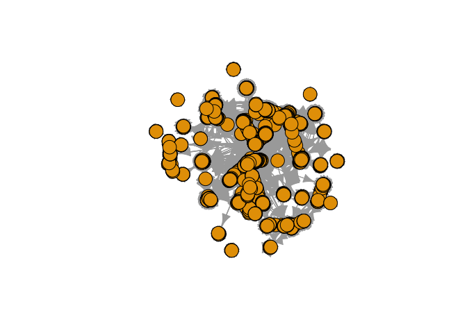

```r
plot(g, vertex.label= NA, layout = layout_nicely(g))
```

Already we could see there nodes more on the outskirt, the lonely islands in terms of air traffic

# 2. Centrality Measures

```r
#Run all measurements
degree_vec <- degree(g)
betweenness_vec <- betweenness(g)
closeness_vec <- closeness(g)
in_degree_vec <- degree(g, mode = "in")
out_degree_vec <- degree(g, mode = "out")
eigen_vec <- eigen_centrality(g)$vector
```

```r
#Attaching measures to the airport_df
degree_df <- as.data.frame(as.table(degree_vec))
betweenness_df <- as.data.frame(as.table(betweenness_vec))
closeness_df <- as.data.frame(as.table(closeness_vec))
in_degree_df <- as.data.frame(as.table(in_degree_vec))
out_degree_df <- as.data.frame(as.table(out_degree_vec))
eigen_df <- as.data.frame(as.table(eigen_vec))



names(degree_df)[1] <- "id"
names(degree_df)[2] <- "degree"

names(betweenness_df)[1] <- "id"
names(betweenness_df)[2] <- "betweenness"

names(closeness_df)[1] <- "id"
names(closeness_df)[2] <- "closeness"

names(in_degree_df)[1] <- "id"
names(in_degree_df)[2] <- "in_degree"

names(out_degree_df)[1] <- "id"
names(out_degree_df)[2] <- "out_degree"

names(eigen_df)[1] <- "id"
names(eigen_df)[2] <- "eigenvector"

airport_df <-  airport_df %>% left_join(degree_df, by = c("IATA" = "id"))  %>%
                left_join(in_degree_df, by = c("IATA" = "id")) %>%
                left_join(out_degree_df, by = c("IATA" = "id")) %>%
                left_join(betweenness_df, by = c("IATA" = "id")) %>%
                left_join(closeness_df, by = c("IATA" = "id")) %>%
                left_join(eigen_df, by = c("IATA" = "id"))

airport_df <- airport_df[complete.cases(airport_df),]
```

## 2.1 Degree Centrality

### 2.1.1 Maximum & Minimum Degree

```r
max_degree <- max(degree_vec)
min_degree <- min(degree_vec)
print(paste("Maximum degree is", max_degree, "degree."))
```

```
## [1] "Maximum degree is 1826 degree."
```

```r
print(paste("Minimum degree is", min_degree, "degree."))
```

```
## [1] "Minimum degree is 1 degree."
```

```r
max_in_degree <- max(in_degree_vec)
min_in_degree <- min(in_degree_vec)
print(paste("Maximum in degree is", max_in_degree, "degree, which means this airport receives flights  from", max_in_degree, "destinations."))
```

```
## [1] "Maximum in degree is 911 degree, which means this airport receives flights  from 911 destinations."
```

```r
print(paste("Minimum degree is", min_in_degree, "degree, which means this airport doesn't receive any flights."))
```

```
## [1] "Minimum degree is 0 degree, which means this airport doesn't receive any flights."
```

```r
max_out_degree <- max(out_degree_vec)
min_out_degree <- min(out_degree_vec)
print(paste("Maximum out degree is", max_out_degree, "degree, which means this airport receives flights  from", max_out_degree, "destinations."))
```

```
## [1] "Maximum out degree is 915 degree, which means this airport receives flights  from 915 destinations."
```

```r
print(paste("Minimum degree is", min_out_degree, "degree, which means this airport  doesn't have departing flights."))
```

```
## [1] "Minimum degree is 0 degree, which means this airport  doesn't have departing flights."
```

### 2.1.2 Top 20 Degree Airport

```r
top20_degree_df <- airport_df[order(airport_df$degree, decreasing = TRUE),][1:20,c("IATA", "Name", "Country", "City","degree")]
top20_degree_df
```

```
##      IATA                                             Name              Country
## 3483  ATL Hartsfield Jackson Atlanta International Airport        United States
## 3631  ORD             Chicago O'Hare International Airport        United States
## 3171  PEK            Beijing Capital International Airport                China
## 503   LHR                          London Heathrow Airport       United Kingdom
## 1347  CDG          Charles de Gaulle International Airport               France
## 337   FRA                        Frankfurt am Main Airport              Germany
## 3286  LAX                Los Angeles International Airport        United States
## 3471  DFW          Dallas Fort Worth International Airport        United States
## 3598  JFK             John F Kennedy International Airport        United States
## 575   AMS                       Amsterdam Airport Schiphol          Netherlands
## 3208  PVG            Shanghai Pudong International Airport                China
## 3125  SIN                         Singapore Changi Airport            Singapore
## 1187  BCN                  Barcelona International Airport                Spain
## 3726  ICN                    Incheon International Airport          South Korea
```

[output cut: 27 more lines]

```r
#set ggplot theme
world_theme <- theme(panel.background = element_rect(fill = "lightblue",
               colour = "lightblue"),
               panel.grid.major = element_blank(),
               panel.grid.minor = element_blank(),
               # surpress legend
               legend.position = "none",
               axis.line=element_blank(),
               axis.text.x=element_blank(),
               axis.text.y=element_blank(),
               axis.ticks=element_blank(),
               axis.title.x=element_blank(),
               axis.title.y=element_blank())
```

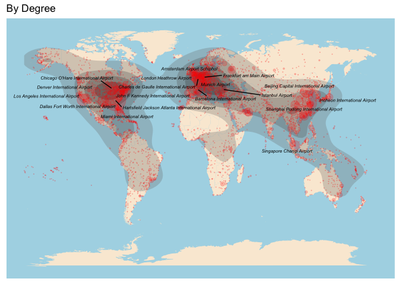

```r
#set lower bound for label showing
thres <-top20_degree_df[20, "degree"]

degree_plot <- ggplot(airport_df, (aes(x = Longtitude, y= Latitude))) +
  borders("world", colour=NA, fill="antiquewhite")  +
  stat_density2d(aes(fill = ..level..,  alpha = I(.3)),
                 size = 1, bins = 5, data = airport_df,
                 geom = "polygon") +
  geom_point(color="red", alpha = .2, size=airport_df$degree/150) +
  # define color of density polygons
  scale_fill_gradient(low = "grey50", high = "grey20") +
  world_theme +
  geom_text_repel(data = subset(airport_df, degree > thres), aes(x=Longtitude, y= Latitude, label=Name), color = "black", fontface = "italic", size = 2, max.overlaps = Inf) + ggtitle("By Degree")

degree_plot
```

```r
top20_in_degree_df <- airport_df[order(airport_df$in_degree, decreasing = TRUE),][1:20,c("IATA", "Name", "Country", "City","in_degree")]
top20_in_degree_df
```

```
##      IATA                                             Name              Country
## 3483  ATL Hartsfield Jackson Atlanta International Airport        United States
## 3631  ORD             Chicago O'Hare International Airport        United States
## 3171  PEK            Beijing Capital International Airport                China
## 503   LHR                          London Heathrow Airport       United Kingdom
## 1347  CDG          Charles de Gaulle International Airport               France
## 3286  LAX                Los Angeles International Airport        United States
## 337   FRA                        Frankfurt am Main Airport              Germany
## 3471  DFW          Dallas Fort Worth International Airport        United States
## 3598  JFK             John F Kennedy International Airport        United States
## 575   AMS                       Amsterdam Airport Schiphol          Netherlands
## 3208  PVG            Shanghai Pudong International Airport                China
## 3125  SIN                         Singapore Changi Airport            Singapore
## 1187  BCN                  Barcelona International Airport                Spain
## 3552  DEN                     Denver International Airport        United States
```

[output cut: 27 more lines]

```r
top20_out_degree_df <- airport_df[order(airport_df$out_degree, decreasing = TRUE),][1:20,c("IATA", "Name", "Country", "City","out_degree")]
top20_out_degree_df
```

```
##      IATA                                             Name              Country
## 3483  ATL Hartsfield Jackson Atlanta International Airport        United States
## 3631  ORD             Chicago O'Hare International Airport        United States
## 3171  PEK            Beijing Capital International Airport                China
## 503   LHR                          London Heathrow Airport       United Kingdom
## 1347  CDG          Charles de Gaulle International Airport               France
## 337   FRA                        Frankfurt am Main Airport              Germany
## 3286  LAX                Los Angeles International Airport        United States
## 3471  DFW          Dallas Fort Worth International Airport        United States
## 3598  JFK             John F Kennedy International Airport        United States
## 575   AMS                       Amsterdam Airport Schiphol          Netherlands
## 3208  PVG            Shanghai Pudong International Airport                China
## 3125  SIN                         Singapore Changi Airport            Singapore
## 1187  BCN                  Barcelona International Airport                Spain
## 3726  ICN                    Incheon International Airport          South Korea
```

[output cut: 27 more lines]

### 2.1.3 Degree Histogram & Statistics

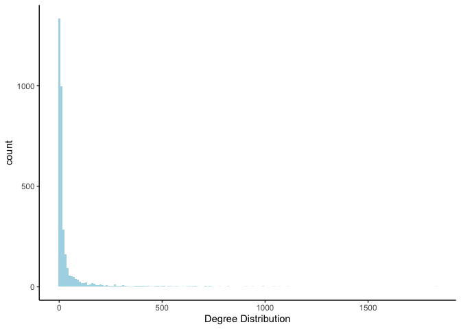

```r
degree_hist <- ggplot(degree_df,aes(x= degree)) +
               geom_histogram(binwidth = 10, fill = "lightblue") +
               xlab(label = "Degree Distribution") +
               theme_classic()
degree_hist
```

```r
psych::describe(degree_df$degree)
```

```
##    vars    n  mean     sd median trimmed mad min  max range skew kurtosis   se
## X1    1 3425 39.51 106.72      8   14.63 8.9   1 1826  1825 6.03    51.73 1.82
```

We could see we have a very right-skewed distribution, as most of the airports have small number of degree, while the top tiers have plenty.

Who are the medians?

```r
eightdegree_df <- airport_df[which(airport_df$degree==8),c("IATA", "Name", "Country", "City","degree")]

sample_n(eightdegree_df, 20)
```

```
##    IATA                                             Name          Country
## 1   DAU                                     Daru Airport Papua New Guinea
## 2   YNG               Youngstown Warren Regional Airport    United States
## 3   PZI                               Bao'anying Airport            China
## 4   UUA                                  Bugulma Airport           Russia
## 5   YYH                                 Taloyoak Airport           Canada
## 6   YHO                                 Hopedale Airport           Canada
## 7   BYC                                  Yacuiba Airport          Bolivia
## 8   NHV                                Nuku Hiva Airport French Polynesia
## 9   OUL                                     Oulu Airport          Finland
## 10  ABA                                   Abakan Airport           Russia
## 11  AVA                       Anshun Huangguoshu Airport            China
## 12  HUH                             Huahine-Fare Airport French Polynesia
## 13  YBG                                   CFB Bagotville           Canada
## 14  YUT                              Repulse Bay Airport           Canada
```

[output cut: 27 more lines]

These are mostly regional airport which travel to and from 4 other airports.

### 2.1.4 In Degree & Out Degree Difference

```r
airport_df$degree_diff <- with(airport_df, out_degree - in_degree)
```

```r
most_outgoing <- airport_df[order(airport_df$degree_diff, decreasing = TRUE),][1:20,]
most_outgoing[,c("IATA", "Name", "Country", "City","in_degree", "out_degree")]
```

```
##      IATA                                                       Name
## 2003  JED                       King Abdulaziz International Airport
## 3367  HOU                                    William P Hobby Airport
## 343   MUC                                             Munich Airport
## 3129  BNE                             Brisbane International Airport
## 3631  ORD                       Chicago O'Hare International Airport
## 1318  MRS                                 Marseille Provence Airport
## 1347  CDG                    Charles de Gaulle International Airport
## 3479  STL                     St Louis Lambert International Airport
## 3548  MDW                       Chicago Midway International Airport
## 3168  SYD               Sydney Kingsford Smith International Airport
## 3515  IAD                    Washington Dulles International Airport
## 3659  MSP Minneapolis-St Paul International/Wold-Chamberlain Airport
## 3896  JIB                                   Djibouti-Ambouli Airport
## 474   MAN                                         Manchester Airport
```

[output cut: 27 more lines]

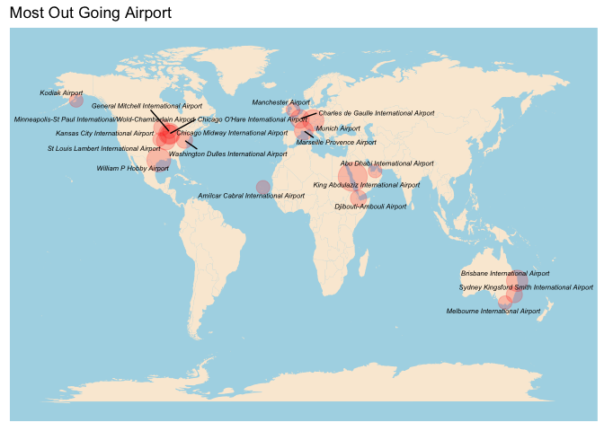

```r
out_going_plot <- ggplot(most_outgoing, (aes(x = Longtitude, y= Latitude))) +
  borders("world", colour=NA, fill="antiquewhite")  +
  world_theme +
  geom_point(color="red", alpha = .2, size=most_outgoing$degree_diff) +
  geom_text_repel(data = most_outgoing, (aes(x=Longtitude, y= Latitude, label=Name)), color = "black", fontface = "italic", size = 2, max.overlaps = Inf) +
  ggtitle("Most Out Going Airport")

out_going_plot
```

```r
most_incoming <- airport_df[order(airport_df$degree_diff, decreasing = FALSE),][1:20,]
most_incoming[,c("IATA", "Name", "Country", "City","in_degree", "out_degree")]
```

```
##      IATA                                              Name        Country
## 1937  AKL                    Auckland International Airport    New Zealand
## 2005  MED             Prince Mohammad Bin Abdulaziz Airport   Saudi Arabia
## 3663  PWM            Portland International Jetport Airport  United States
## 3552  DEN                      Denver International Airport  United States
## 73    YHZ         Halifax / Stanfield International Airport         Canada
## 3736  ATH       Eleftherios Venizelos International Airport         Greece
## 4027  CRW                                    Yeager Airport  United States
## 1596  LIS Humberto Delgado Airport (Lisbon Portela Airport)       Portugal
## 3264  PHX          Phoenix Sky Harbor International Airport  United States
## 3286  LAX                 Los Angeles International Airport  United States
## 3678  LAS                    McCarran International Airport  United States
## 3788  PMI                         Palma De Mallorca Airport          Spain
## 983   HRE       Robert Gabriel Mugabe International Airport       Zimbabwe
## 1239  TLS                          Toulouse-Blagnac Airport         France
```

[output cut: 27 more lines]

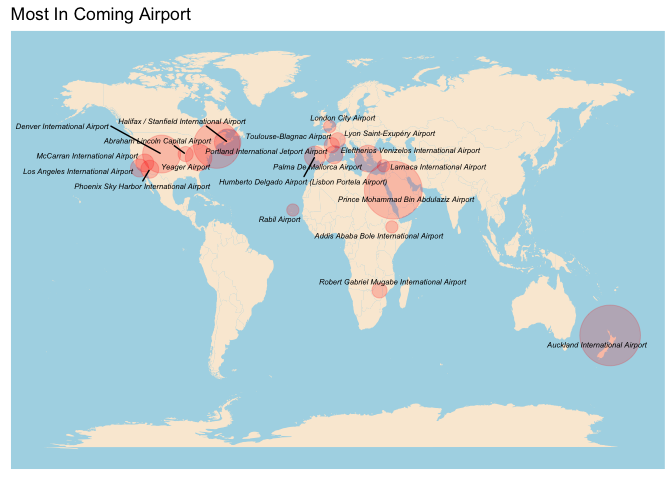

```r
in_coming_plot <- ggplot(most_incoming, (aes(x = Longtitude, y= Latitude))) +
  borders("world", colour=NA, fill="antiquewhite")  +
  world_theme +
  geom_point(color="red", alpha = .2, size=abs(most_incoming$degree_diff)) +
  geom_text_repel(data = most_incoming, (aes(x=Longtitude, y= Latitude, label=Name)), color = "black", fontface = "italic", size = 2, max.overlaps = Inf) +
  ggtitle("Most In Coming Airport")

in_coming_plot
```

Interestingly, the two Saudi airports Prince Mohammad Bin Abdulaziz Airport in Madinah and King Abdulaziz International Airport in Jeddah, both ranked high for the degree differences, one for incoming one for out going. It may suggest that a lot of people are visiting Saudi Arabia by entering Madinah and leaving through Jeddah, that’s why more routes are accommodating such needs.

## 2.2 Betweenness Centrality

```r
top20_betweenness_df <- airport_df[order(airport_df$betweenness, decreasing = TRUE),][1:20,]
top20_betweenness_df[,c("IATA", "Name", "Country", "City","betweenness")]
```

```
##      IATA                                                              Name
## 3286  LAX                                 Los Angeles International Airport
## 3575  ANC                       Ted Stevens Anchorage International Airport
## 1347  CDG                           Charles de Gaulle International Airport
## 503   LHR                                           London Heathrow Airport
## 3631  ORD                              Chicago O'Hare International Airport
## 3171  PEK                             Beijing Capital International Airport
## 2101  DXB                                       Dubai International Airport
## 337   FRA                                         Frankfurt am Main Airport
## 3378  SEA                              Seattle Tacoma International Airport
## 2437  GRU Guarulhos - Governador André Franco Montoro International Airport
## 3125  SIN                                          Singapore Changi Airport
## 192   YYZ                           Lester B. Pearson International Airport
## 575   AMS                                        Amsterdam Airport Schiphol
## 3483  ATL                  Hartsfield Jackson Atlanta International Airport
```

[output cut: 27 more lines]

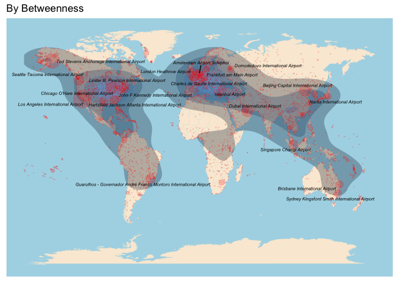

```r
#set lower bound for label showing
thres <-top20_betweenness_df[20, "betweenness"]

betweenness_plot <- ggplot(airport_df, (aes(x = Longtitude, y= Latitude))) +
  borders("world", colour=NA, fill="antiquewhite")  +
  stat_density2d(aes(fill = ..level..,  alpha = I(.3)),
                 size = 1, bins = 5, data = airport_df,
                 geom = "polygon") +
  geom_point(color="red", alpha = .2, size=airport_df$betweenness/100000) +
  world_theme +
geom_text_repel(data = subset(airport_df, betweenness>= thres), aes(x=Longtitude, y= Latitude, label=Name), color = "black", fontface = "italic", size = 2, max.overlaps = Inf) +
  ggtitle("By Betweenness")

betweenness_plot
```

Which airports are Top Betweenness but not Top Degree?

```r
`%nin%` = Negate(`%in%`)

for (i in top20_betweenness_df$Name){
  if (i %nin% top20_degree_df$Name){
    print(i)
  }
}
```

```
## [1] "Ted Stevens Anchorage International Airport"
## [1] "Seattle Tacoma International Airport"
## [1] "Guarulhos - Governador André Franco Montoro International Airport"
## [1] "Lester B. Pearson International Airport"
## [1] "Sydney Kingsford Smith International Airport"
## [1] "Brisbane International Airport"
## [1] "Domodedovo International Airport"
## [1] "Narita International Airport"
```

## 2.3 Closeness Centrality

```r
top20_closeness_df <- airport_df[order(airport_df$closeness, decreasing = TRUE),][1:20,]
top20_closeness_df[,c("IATA", "Name", "Country", "City","closeness")]
```

```
##      IATA                                    Name              Country
## 3884  YWH          Victoria Harbour Seaplane Base               Canada
## 4207  CXH       Vancouver Harbour Water Aerodrome               Canada
## 4771  LPS                    Lopez Island Airport        United States
## 337   FRA               Frankfurt am Main Airport              Germany
## 1561  VDA              Ovda International Airport               Israel
## 1347  CDG Charles de Gaulle International Airport               France
## 503   LHR                 London Heathrow Airport       United Kingdom
## 2101  DXB             Dubai International Airport United Arab Emirates
## 575   AMS              Amsterdam Airport Schiphol          Netherlands
## 3286  LAX       Los Angeles International Airport        United States
## 3598  JFK    John F Kennedy International Airport        United States
## 192   YYZ Lester B. Pearson International Airport               Canada
## 7630  IST                        Istanbul Airport               Turkey
## 3631  ORD    Chicago O'Hare International Airport        United States
```

[output cut: 27 more lines]

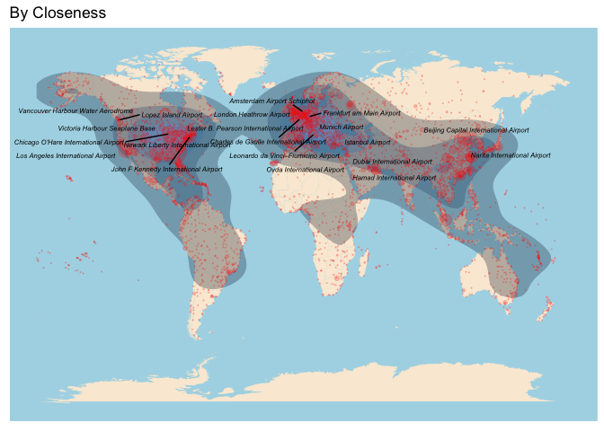

```r
#set lower bound for label showing
thres <-top20_closeness_df[20, "closeness"]

closeness_plot <- ggplot(airport_df, (aes(x = Longtitude, y= Latitude))) +
  borders("world", colour=NA, fill="antiquewhite")  +
  stat_density2d(aes(fill = ..level..,  alpha = I(.3)),
                 size = 1, bins = 5, data = airport_df,
                 geom = "polygon") +
  geom_point(color="red", alpha = .2, size=airport_df$degree/200) +
  world_theme +
geom_text_repel(data = subset(airport_df, closeness >= thres), aes(x=Longtitude, y= Latitude, label=Name), color = "black", fontface = "italic", size = 2, max.overlaps = Inf) +
  ggtitle("By Closeness")

closeness_plot
```

```r
for (i in top20_closeness_df$Name){
  if (i %nin% top20_degree_df$Name){
    print(i)
  }
}
```

```
## [1] "Victoria Harbour Seaplane Base"
## [1] "Vancouver Harbour Water Aerodrome"
## [1] "Lopez Island Airport"
## [1] "Ovda International Airport"
## [1] "Lester B. Pearson International Airport"
## [1] "Narita International Airport"
## [1] "Leonardo da Vinci–Fiumicino Airport"
## [1] "Newark Liberty International Airport"
## [1] "Hamad International Airport"
```

## 2.4 Eigenvector Centrality

```r
top20_eigen_df <- airport_df[order(airport_df$eigenvector, decreasing = TRUE),][1:20,]
top20_eigen_df[,c("IATA", "Name", "Country", "City","eigenvector")]
```

```
##      IATA                                             Name        Country
## 3483  ATL Hartsfield Jackson Atlanta International Airport  United States
## 503   LHR                          London Heathrow Airport United Kingdom
## 3631  ORD             Chicago O'Hare International Airport  United States
## 3598  JFK             John F Kennedy International Airport  United States
## 3286  LAX                Los Angeles International Airport  United States
## 1347  CDG          Charles de Gaulle International Airport         France
## 3471  DFW          Dallas Fort Worth International Airport  United States
## 337   FRA                        Frankfurt am Main Airport        Germany
## 3271  SFO              San Francisco International Airport  United States
## 192   YYZ          Lester B. Pearson International Airport         Canada
## 575   AMS                       Amsterdam Airport Schiphol    Netherlands
## 3171  PEK            Beijing Capital International Airport          China
## 3377  MIA                      Miami International Airport  United States
## 3552  DEN                     Denver International Airport  United States
```

[output cut: 27 more lines]

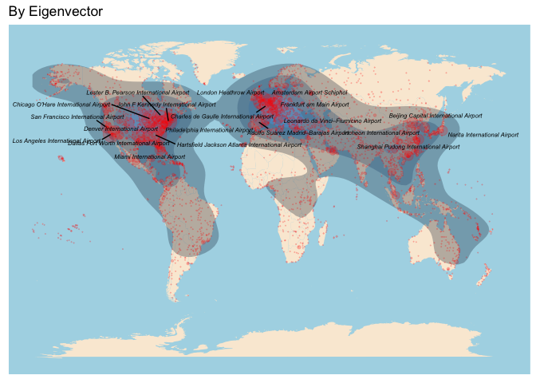

```r
#set lower bound for label showing
thres <-top20_eigen_df[20, "eigenvector"]

eigen_plot <- ggplot(airport_df, (aes(x = Longtitude, y= Latitude))) +
  borders("world", colour=NA, fill="antiquewhite")  +
  stat_density2d(aes(fill = ..level..,  alpha = I(.3)),
                 size = 1, bins = 5, data = airport_df,
                 geom = "polygon") +
  geom_point(color="red", alpha = .2, size=airport_df$eigenvector*10) +
  world_theme +
geom_text_repel(data = subset(airport_df, eigenvector >= thres), aes(x=Longtitude, y= Latitude, label=Name), color = "black", fontface = "italic", size = 2, max.overlaps = Inf) +
  ggtitle("By Eigenvector")

eigen_plot
```

```r
for (i in top20_eigen_df$Name){
  if (i %nin% top20_degree_df$Name){
    print(i)
  }
}
```

```
## [1] "San Francisco International Airport"
## [1] "Lester B. Pearson International Airport"
## [1] "Narita International Airport"
## [1] "Leonardo da Vinci–Fiumicino Airport"
## [1] "Adolfo Suárez Madrid–Barajas Airport"
## [1] "Philadelphia International Airport"
```

# 3. Comunnity detection

We are using the quicker method fastgreedy, so we will have to remove direction from our graph.

## 3.1 Sizes of Communities

```r
graph <- as.undirected(g)
graph <- simplify(graph)
fastgreedy_communities <- fastgreedy.community(graph)
V(graph)$community <- fastgreedy_communities$membership

sizes(fastgreedy_communities)
```

```
## Community sizes
##   1   2   3   4   5   6   7   8   9  10  11  12  13  14  15  16  17  18  19  20
## 732 898 800 183  74 155  52 178  37  12  17  12  19   7  25  15   7  18   9  13
##  21  22  23  24  25  26  27  28  29  30  31  32  33  34  35  36  37  38  39  40
##   8   6   6   6  22   5  10   8   4   4  23   4   7   3   3   7   3   4   4   3
##  41  42  43  44  45  46  47  48  49
##   3   4   3   2   2   2   2   2   2
```

We have obtained 49 communities, we will explore the biggest 4.

## 3.2 Initial Plotting

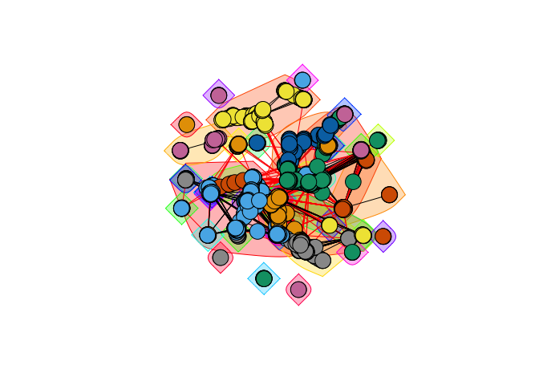

```r
plot(fastgreedy_communities, graph, vertex.label = NA)
```

```r
#Attaching community id to the airport_df
membership_vec <- membership(fastgreedy_communities)
membership_df <-as.data.frame(as.table(membership_vec))
names(membership_df)[1] <- "id"
names(membership_df)[2] <- "community id"
airport_df <-airport_df %>% left_join(membership_df, by = c("IATA" = "id"))
```

We will then take samples of 20 to see how are these communities formed.

```r
sample_n(airport_df[airport_df$`community id` == 1,], 20)[,c("IATA", "Country","Name")]
```

```
##    IATA        Country                                              Name
## 1   SLM          Spain                                 Salamanca Airport
## 2   MZH         Turkey                           Amasya Merzifon Airport
## 3   EGO         Russia                    Belgorod International Airport
## 4   LRS         Greece                                     Leros Airport
## 5   HER         Greece Heraklion International Nikos Kazantzakis Airport
## 6   OUA   Burkina Faso                               Ouagadougou Airport
## 7   SFL     Cape Verde                                São Filipe Airport
## 8   AKX     Kazakhstan                                    Aktobe Airport
## 9   JSY         Greece                                     Syros Airport
## 10  CEG United Kingdom                                  Hawarden Airport
## 11  AQJ         Jordan          Aqaba King Hussein International Airport
## 12  BIA         France                            Bastia-Poretta Airport
## 13  PSA          Italy                        Pisa International Airport
## 14  LDE         France                   Tarbes-Lourdes-Pyrénées Airport
## 15  PAS         Greece                            Paros National Airport
## 16  DTM        Germany                                  Dortmund Airport
## 17  LPL United Kingdom                     Liverpool John Lennon Airport
## 18  MQM         Turkey                                    Mardin Airport
## 19  ECN         Cyprus                       Ercan International Airport
## 20  NCE         France                          Nice-Côte d'Azur Airport
```

```r
sample_n(airport_df[airport_df$`community id` == 2,], 20)[,c("IATA", "Country","Name")]
```

```
##    IATA      Country                                      Name
## 1   KET        Burma                          Kengtung Airport
## 2   YCU        China                 Yuncheng Guangong Airport
## 3   TIF Saudi Arabia                    Ta’if Regional Airport
## 4   LDH    Australia                  Lord Howe Island Airport
## 5   WXN        China                           Wanxian Airport
## 6   IXZ        India        Vir Savarkar International Airport
## 7   HDY     Thailand             Hat Yai International Airport
## 8   HET        China               Baita International Airport
## 9   HTN        China                             Hotan Airport
## 10  BJB         Iran                           Bojnord Airport
## 11  BDP        Nepal                         Bhadrapur Airport
## 12  COK        India              Cochin International Airport
## 13  KUU        India                      Kullu Manali Airport
## 14  WAE Saudi Arabia                   Wadi Al Dawasir Airport
## 15  HIN  South Korea                  Sacheon Air Base/Airport
## 16  MKY    Australia                            Mackay Airport
## 17  BDO    Indonesia Husein Sastranegara International Airport
## 18  DSN        China                   Ordos Ejin Horo Airport
## 19  TDX     Thailand                              Trat Airport
## 20  MWF      Vanuatu                       Maewo-Naone Airport
```

```r
sample_n(airport_df[airport_df$`community id` == 3,], 20)[,c("IATA", "Country","Name")]
```

```
##    IATA                  Country
## 1   PLN            United States
## 2   PUQ                    Chile
## 3   BRL            United States
## 4   CHS            United States
## 5   XSC Turks and Caicos Islands
## 6   QBC                   Canada
## 7   DBQ            United States
## 8   UPN                   Mexico
## 9   YCD                   Canada
## 10  CAY            French Guiana
## 11  YGP                   Canada
## 12  YQL                   Canada
## 13  SHD            United States
## 14  TWF            United States
```

[output cut: 27 more lines]

```r
sample_n(airport_df[airport_df$`community id` == 4,], 20)[,c("IATA", "Country","Name")]
```

```
##    IATA       Country                       Name
## 1   HUS United States             Hughes Airport
## 2   SKK United States         Shaktoolik Airport
## 3   NLG United States      Nelson Lagoon Airport
## 4   KPN United States             Kipnuk Airport
## 5   BTI United States Barter Island LRRS Airport
## 6   SNP United States     St Paul Island Airport
## 7   ADK United States               Adak Airport
## 8   ADQ United States             Kodiak Airport
## 9   BKC United States           Buckland Airport
## 10  FYU United States         Fort Yukon Airport
## 11  AKN United States        King Salmon Airport
## 12  KAL United States             Kaltag Airport
## 13  HNS United States             Haines Airport
## 14  NUI United States            Nuiqsut Airport
## 15  SDP United States         Sand Point Airport
## 16  CYF United States          Chefornak Airport
## 17  RSH United States    Russian Mission Airport
## 18  GST United States           Gustavus Airport
## 19  DLG United States         Dillingham Airport
## 20  SMK United States         St Michael Airport
```

```r
community_1 <- airport_df %>% dplyr::filter(`community id` == 1)
community_2 <- airport_df %>% dplyr::filter(`community id` == 2)
community_3 <- airport_df %>% dplyr::filter(`community id` == 3)
community_4 <- airport_df %>% dplyr::filter(`community id` == 4)
```

## 3.3 Graphing the Communities

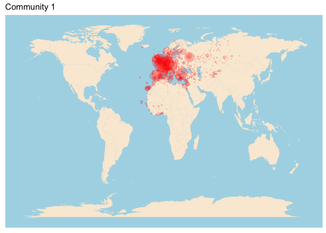

```r
community_1_plot <- ggplot(community_1, (aes(x = Longtitude, y= Latitude))) +
  borders("world", colour=NA, fill="antiquewhite")  +
  world_theme +
  geom_point(color="red", alpha = .2, size=community_1$degree/100) +
  ggtitle("Community 1")

community_1_plot
```

Community 1 is focused on Europe, a bit of Middle East and some coastal part of Africa.

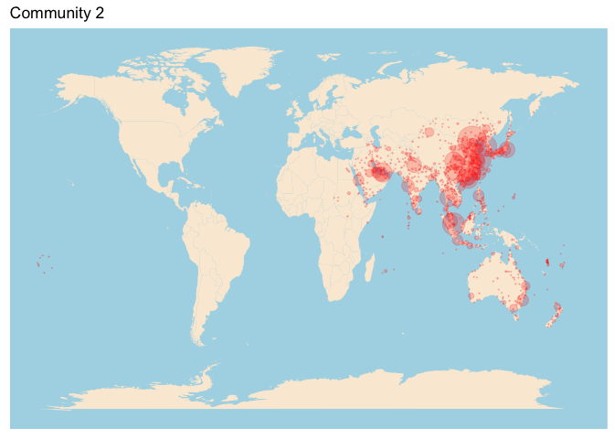

```r
community_2_plot <- ggplot(community_2, (aes(x = Longtitude, y= Latitude))) +
  borders("world", colour=NA, fill="antiquewhite")  +
  world_theme +
  geom_point(color="red", alpha = .2, size=community_2$degree/100) +
  ggtitle("Community 2")

community_2_plot
```

Community 2 is focused on the Asia-Pacific, Central Asia and Middle East.

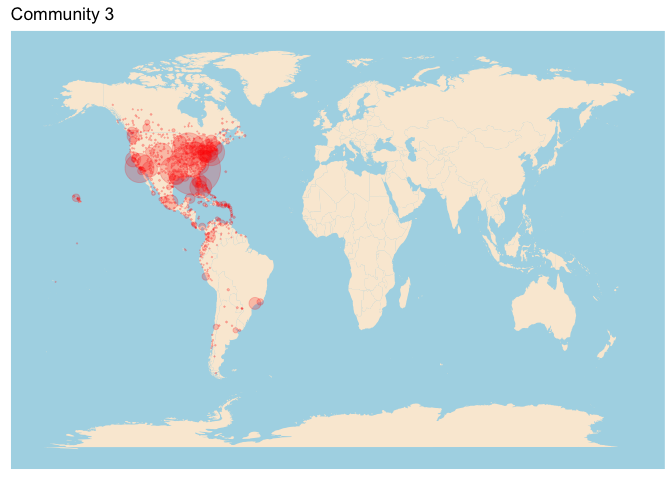

```r
community_3_plot <- ggplot(community_3, (aes(x = Longtitude, y= Latitude))) +
  borders("world", colour=NA, fill="antiquewhite")  +
  world_theme +
  geom_point(color="red", alpha = .2, size=community_3$degree/100) +
  ggtitle("Community 3")

community_3_plot
```

Community 3 is focused in US and some parts of Central & South America.

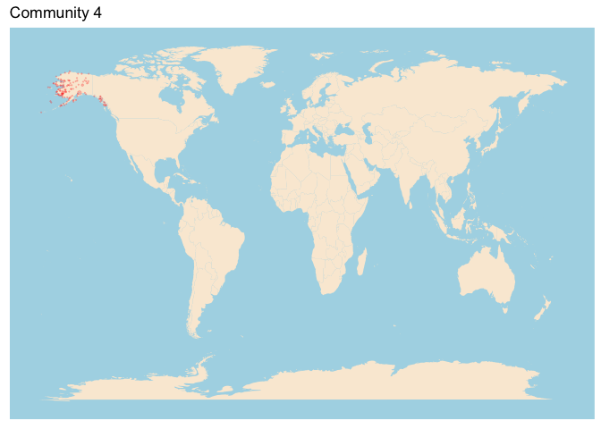

```r
community_4_plot <- ggplot(community_4, (aes(x = Longtitude, y= Latitude))) +
  borders("world", colour=NA, fill="antiquewhite")  +
  world_theme +
  geom_point(color="red", alpha = .2, size=community_4$degree/100) +
  ggtitle("Community 4")

community_4_plot
```

Community 4 is mostly centralized in Alaska, with few routes.

# 4. Insights & Analysis

## 4.1 Where are these routes flying from and to?

```r
country_origin_df <- airport_df %>% dplyr::select("IATA","Country") %>% dplyr::rename(source.airport=IATA)
df_1 <- merge(x = routes_df, y = country_origin_df, by = "source.airport", all.x = TRUE)
df_1 <- df_1 %>% dplyr::rename(Country_origin=Country)

country_destination_df <- airport_df %>% dplyr::select("IATA","Country") %>% dplyr::rename(destination.airport=IATA)
df_2 <- merge(x = df_1, y = country_destination_df, by = "destination.airport", all.x = TRUE)
df_2 <- df_2 %>% dplyr::rename(Country_destination=Country)

df3 <- df_2 %>% dplyr::count(Country_origin, Country_destination, sort=TRUE)
df3 <- df3 %>%dplyr::rename(number_of_routes=n, source=Country_origin, target=Country_destination)
df3[1:30,]
```

```
##            source         target number_of_routes
## 1   United States  United States            10518
## 2           China          China             6877
## 3          Brazil         Brazil             1195
## 4          Canada         Canada             1167
## 5           India          India             1057
## 6          Russia         Russia              964
## 7       Australia      Australia              776
## 8           Japan          Japan              623
## 9       Indonesia      Indonesia              611
## 10          Spain          Spain              579
## 11         Mexico         Mexico              577
## 12 United Kingdom          Spain              518
## 13          Spain United Kingdom              512
## 14         France         France              483
```

[output cut: 16 more lines]

We could see most popular routes are domestic,and are from countries that are either big geographically or population-wise. Then some of the most popular internal routes are:

- UK to Spain
- Spain to UK
- Mexico to US

## 4.2 Diameter

Diameter: Which is the longest route?

```r
diameter_routes <- diameter(g, directed = TRUE)
print(paste("The diameter of the route graph is", diameter_routes, ", which means one person can go to", diameter_routes, "cities in one go without repeating the places this person has been."))
```

```
## [1] "The diameter of the route graph is 14 , which means one person can go to 14 cities in one go without repeating the places this person has been."
```

```r
diameter_stops <- get_diameter(g)
diameter_stops <- as.vector(names(diameter_stops))
diameter_df <- airport_df[match(diameter_stops, airport_df$IATA),]
diameter_df <- diameter_df[complete.cases(diameter_df),]
diameter_df
```

```
##      Airport.ID                                                    Name
## 2340       5535                                         Salluit Airport
## 2318       5504                                        Ivujivik Airport
## 2319       5506                                        Akulivik Airport
## 2879       6727                                      Puvirnituq Airport
## 40           62                               La Grande Rivière Airport
## 90          146 Montreal / Pierre Elliott Trudeau International Airport
## 759        1665                   Geneva Cointrin International Airport
## 298         609                              Copenhagen Kastrup Airport
## 9             9                                   Kangerlussuaq Airport
## 7             7                                      Narsarsuaq Airport
## 2275       5442                                       Qaqortoq Heliport
## 2277       5444                                     Nanortalik Heliport
##                   City     Country IATA Latitude Longtitude degree in_degree
## 2340           Salluit      Canada  YZG 62.17940  -75.66720      4         2
```

[output cut: 24 more lines]

```r
diameter_plot <- ggplot(diameter_df, (aes(x = Longtitude, y= Latitude))) +
  borders("world", colour=NA, fill="antiquewhite")  +
  world_theme +
  geom_point(color="red", alpha = .5, size=2) +
  geom_text_repel(aes(label=Name), color = "black", fontface = "italic", size = 2, max.overlaps = Inf)
```

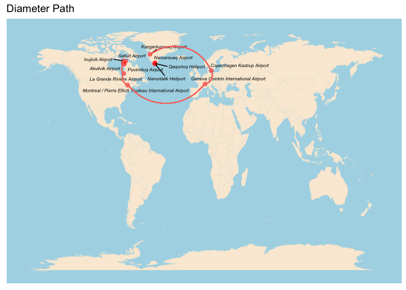

```r
x1 <- diameter_df[1,"Longtitude"]
x2 <- diameter_df[2,"Longtitude"]
x3 <- diameter_df[3,"Longtitude"]
x4 <- diameter_df[4,"Longtitude"]
x5 <- diameter_df[5,"Longtitude"]
x6 <- diameter_df[6,"Longtitude"]
x7 <- diameter_df[7,"Longtitude"]
x8 <- diameter_df[8,"Longtitude"]
x9 <- diameter_df[9,"Longtitude"]

y1 <- diameter_df[1,"Latitude"]
y2 <- diameter_df[2,"Latitude"]
y3 <- diameter_df[3,"Latitude"]
y4 <- diameter_df[4,"Latitude"]
y5 <- diameter_df[5,"Latitude"]
y6 <- diameter_df[6,"Latitude"]
y7 <- diameter_df[7,"Latitude"]
y8 <- diameter_df[8,"Latitude"]
y9 <- diameter_df[9,"Latitude"]


diameter_plot +
geom_curve(aes(x = x1, y = y1, xend = x2, yend = y2, colour = "black")) +
geom_curve(aes(x = x2, y = y2, xend = x3, yend = y3, colour = "black")) +
geom_curve(aes(x = x3, y = y3, xend = x4, yend = y4, colour = "black")) +
geom_curve(aes(x = x4, y = y4, xend = x5, yend = y5, colour = "black")) +
geom_curve(aes(x = x5, y = y5, xend = x6, yend = y6, colour = "black")) +
geom_curve(aes(x = x6, y = y6, xend = x7, yend = y7, colour = "black")) +
geom_curve(aes(x = x7, y = y7, xend = x8, yend = y8, colour = "black")) +
geom_curve(aes(x = x8, y = y8, xend = x9, yend = y9, colour = "black")) +
ggtitle("Diameter Path")
```

## 4.3 Zoom in on Specific Cities

Where are the the places connected to Madrid

```r
#CREATING SUBFRAMES WITH THE LATITUDE AND LONGITUDE FOR THE AIRPORT OF DEPARTURE AND THE AIRPORT OF ARRIVAL

coords_origin <- airport_df %>% dplyr::select('Airport.ID', 'Latitude', 'Longtitude') %>% dplyr::rename(SourceLat=Latitude,SourceLong=Longtitude)

coords_destiny <- airport_df %>% dplyr::select('Airport.ID', 'Latitude', 'Longtitude') %>% dplyr::rename(DestLat=Latitude, DestLong=Longtitude)

flights_to_from <- routes_df %>%
  filter((routes_df$source.airport=="MAD") |     (routes_df$destination.airport=="MAD"))

#MERGING WITH ROUTES DATAFRAME BUT USING THE AIRPORT OF DEPARTURE AS COMMON COLUMN
flights_coords_origin <- merge(flights_to_from, coords_origin, by.x='source.airport.id', by.y='Airport.ID' )

#MERGING THE DATAFRAME FLIGHTS_COORDS_ORIGIN WITH THE COORDINATES OF ARRIVAL USING THE AIRPORT OF ARRIVAL AS COMMON COLUMN
flights_coords_destination <- merge(flights_to_from, coords_destiny, by.x='destination.airport.id', by.y='Airport.ID')

flights_with_coords <- merge(flights_coords_origin, flights_coords_destination)

#SUBFRAMING AND EXTRACTING ONLY COORDINATES OF ORIGIN AND DESTINATION
coords <- flights_with_coords %>% dplyr::select('SourceLat','SourceLong','DestLat','DestLong')
```

```r
#CREATING DATAFRAME WITH THE COORDINATES OF ORIGIN
source_df<-data.frame(SourceLong=coords$SourceLong,SourceLat=coords$SourceLat)
#TRANSFORMING THEM INTO SPATIALPOINTS
source_sp<-SpatialPoints(source_df, proj4string=CRS("+proj=longlat"))
#CREATING A DATAFRAME OUT OF THOSE POINTS
source_spdf <- SpatialPointsDataFrame(source_sp, data = source_df)
```

```r
#CREATING DATAFRAME WITH THE COORDINATES OF DESTINATION
dest_df<-data.frame(SourceLong=coords$DestLong,SourceLat=coords$DestLat)
#TRANSFORMING THEM INTO SPATIALPOINTS
dest_sp<-SpatialPoints(dest_df, proj4string=CRS("+proj=longlat"))
#CREATING A DATAFRAME OUT OF THOSE POINTS
dest_spdf <- SpatialPointsDataFrame(dest_sp, data = dest_df)
```

```r
comb_df<-data.frame(coords)
comb_df$distance<-distHaversine(source_sp,dest_sp)
```

```r
#ALLOWS US TO RETRIEVE THE MOST COMMON FLIGHTS BY COORDINATES
source_da   <- factor(sprintf("%.2f:%.2f",comb_df[,2], comb_df[,1]))
freq <- sort(table(source_da), decreasing=TRUE)
frequent_destinations <- names(freq)[1:50]
idx <- source_da %in% frequent_destinations
LongLat <- unique(comb_df[idx,1:2])
frequent_flights <-comb_df[idx,]
```

```r
#PLOTTING THE DATAFRAME SO WE GET THE GLOBE
(earth <- system.file("images/world.jpg",  package="threejs"))
```

```
## [1] "/Library/Frameworks/R.framework/Versions/4.0/Resources/library/threejs/images/world.jpg"
```

```r
test_df <- data.frame(origin_lat = comb_df[,1], origin_long = comb_df[,2], dest_lat = comb_df[,3], dest_long = comb_df[,4])
#
globejs(img=earth, lat=LongLat[,1], long=LongLat[,2], arcs=test_df,
        arcsHeight=0.3, arcsLwd=2, arcsColor="red", arcsOpacity=0.15,
        atmosphere=TRUE,bg="white", height = 800 , width = 800)
```

[interactive chart not shown]

## 4.4 Travelling Between 2 Specific Stops

If I’m a consultant based in Madrid and I go to Shanghai every month, which airline should I pick?

```r
distances(g, "MAD", "PVG")
```

```
##     PVG
## MAD   2
```

```r
n_mad <- neighbors(g, "MAD", mode = c('in'))
n_pvg <- neighbors(g, "PVG", mode = c('out'))
middle_stops <- as.table(intersection(n_mad, n_pvg))
names(middle_stops)
```

```
##  [1] "ZRH" "ORD" "BKK" "MUC" "AMS" "ICN" "PEK" "LAX" "DXB" "JFK" "CDG" "FCO"
## [13] "FRA" "HEL" "LHR" "MXP" "SVO" "CPH" "IST" "DOH" "EWR"
```

```r
tempdf <- routes_df %>% dplyr::select("airline","source.airport", "destination.airport") %>% dplyr::rename(source = source.airport, dest = destination.airport)

tempdf1 <- tempdf %>% dplyr::filter(source == "MAD") %>% dplyr::rename(airline1 = airline)

tempdf2 <- tempdf %>% dplyr::filter(dest == "PVG") %>% dplyr::rename(airline2 = airline)
```

```r
sqldf("select tempdf1.*, tempdf2.* from tempdf1, tempdf2 where (tempdf1.dest = tempdf2.source) and airline1 = airline2")
```

```
##    airline1 source dest airline2 source dest
## 1        AA    MAD  LAX       AA    LAX  PVG
## 2        AA    MAD  ORD       AA    ORD  PVG
## 3        AF    MAD  CDG       AF    CDG  PVG
## 4        AY    MAD  HEL       AY    HEL  PVG
## 5        AZ    MAD  FCO       AZ    FCO  PVG
## 6        BA    MAD  LHR       BA    LHR  PVG
## 7        CA    MAD  PEK       CA    PEK  PVG
## 8        DL    MAD  JFK       DL    JFK  PVG
## 9        EK    MAD  DXB       EK    DXB  PVG
## 10       KE    MAD  ICN       KE    ICN  PVG
## 11       KL    MAD  AMS       KL    AMS  PVG
## 12       LH    MAD  FRA       LH    FRA  PVG
## 13       LH    MAD  MUC       LH    MUC  PVG
## 14       LX    MAD  ZRH       LX    ZRH  PVG
## 15       MU    MAD  AMS       MU    AMS  PVG
## 16       QR    MAD  DOH       QR    DOH  PVG
## 17       SK    MAD  CPH       SK    CPH  PVG
## 18       SU    MAD  SVO       SU    SVO  PVG
## 19       TG    MAD  BKK       TG    BKK  PVG
## 20       TK    MAD  IST       TK    IST  PVG
## 21       UA    MAD  EWR       UA    EWR  PVG
```

## 4.5 Adding Passenger Volume

Are the busiest airport really busy? We wanted to add the passenger volume to the data set to evaluate their relation with degree relationship. As the free & available data only has ranked 20 airports, we will do it on a small scale.

```r
passenger_url <- "https://gist.githubusercontent.com/hannahbhchou/01cbc0081c8a080350e50d0ead1a1fcc/raw/33f3a9b29ae6a7323ace128f94775025d23485cb/passenger_2017.csv"

passenger_df <- read.csv(passenger_url, header = TRUE)
```

```r
passenger_df <- passenger_df %>% left_join(airport_df, by = c("IATA" = "IATA"))
passenger_df$v_d_ratio <- with(passenger_df, Volume / degree)
```

```r
passenger_df[,c("IATA", "Name", "Volume", "degree", "v_d_ratio")]
```

```
##    IATA                                             Name    Volume degree
## 1   ATL Hartsfield Jackson Atlanta International Airport 103902992   1826
## 2   PEK            Beijing Capital International Airport  95786442   1069
## 3   DXB                      Dubai International Airport  88242099    710
## 4   HND               Tokyo Haneda International Airport  85408975    315
## 5   LAX                Los Angeles International Airport  84557968    990
## 6   ORD             Chicago O'Hare International Airport  79828183   1108
## 7   LHR                          London Heathrow Airport  78014598   1051
## 8   HKG                  Hong Kong International Airport  72664075    710
## 9   PVG            Shanghai Pudong International Airport  70001237    825
## 10  CDG          Charles de Gaulle International Airport  69471442   1041
## 11  AMS                       Amsterdam Airport Schiphol  68515425    903
## 12  DFW          Dallas Fort Worth International Airport  67092194    936
## 13  CAN           Guangzhou Baiyun International Airport  65887473    674
## 14  FRA                        Frankfurt am Main Airport  64500386    990
```

[output cut: 27 more lines]

One thing we’ve noticed that all of the top 20 passenger volume airports are scattered among the most popular communities, but maybe because of their geography they are separated.

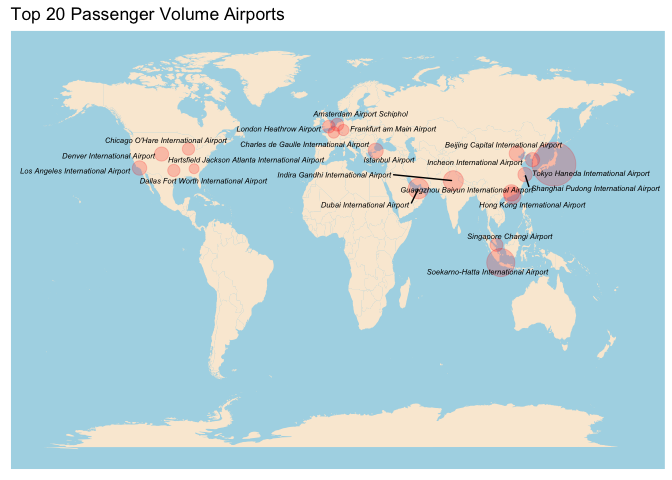

```r
passenger_plot <- ggplot(passenger_df, (aes(x = Longtitude, y= Latitude))) +
  borders("world", colour=NA, fill="antiquewhite")  +
  world_theme +
  geom_point(color="red", alpha = .2, size=passenger_df$v_d_ratio/18000) +
  geom_text_repel( aes(x=Longtitude, y= Latitude, label=Name), color = "black", fontface = "italic", size = 2, max.overlaps = Inf) +
  ggtitle("Top 20 Passenger Volume Airports")

passenger_plot
```

We could see that though Tokyo Haneda airport and Soekarno-Hatta International Airport are the highest in terms of volume/degree ratio, which means for every route they serve more passengers.